# Bank Churn Prediction

### Train and Test Data Split

```python
#Separating the independent and target variables
X = df.iloc[:, :-1]
y = df.iloc[:, -1]
```

```python
X.head()
```

|  | CreditScore | Geography | Gender | Age | Tenure | Balance | NumOfProducts | HasCrCard | IsActiveMember | EstimatedSalary |
| --- | --- | --- | --- | --- | --- | --- | --- | --- | --- | --- |
| 0 | 619 | France | Female | 42 | 2 | 0.00 | 1 | 1 | 1 | 101348.88 |
| 1 | 608 | Spain | Female | 41 | 1 | 83807.86 | 1 | 0 | 1 | 112542.58 |
| 2 | 502 | France | Female | 42 | 8 | 159660.80 | 3 | 1 | 0 | 113931.57 |
| 3 | 699 | France | Female | 39 | 1 | 0.00 | 2 | 0 | 0 | 93826.63 |
| 4 | 850 | Spain | Female | 43 | 2 | 125510.82 | 1 | 1 | 1 | 79084.10 |

```python
y.head()
```

```
0    1
1    0
2    1
3    0
4    0
Name: Exited, dtype: int64
```

```python
#One-Hot encoding the Geography and Gender categorical columns
X_encoded= pd.get_dummies(X, columns=['Geography','Gender'])
X_encoded.head()
```

|  | CreditScore | Age | Tenure | Balance | NumOfProducts | HasCrCard | IsActiveMember | EstimatedSalary | Geography_France | Geography_Germany | Geography_Spain | Gender_Female | Gender_Male |
| --- | --- | --- | --- | --- | --- | --- | --- | --- | --- | --- | --- | --- | --- |
| 0 | 619 | 42 | 2 | 0.00 | 1 | 1 | 1 | 101348.88 | 1 | 0 | 0 | 1 | 0 |
| 1 | 608 | 41 | 1 | 83807.86 | 1 | 0 | 1 | 112542.58 | 0 | 0 | 1 | 1 | 0 |
| 2 | 502 | 42 | 8 | 159660.80 | 3 | 1 | 0 | 113931.57 | 1 | 0 | 0 | 1 | 0 |
| 3 | 699 | 39 | 1 | 0.00 | 2 | 0 | 0 | 93826.63 | 1 | 0 | 0 | 1 | 0 |
| 4 | 850 | 43 | 2 | 125510.82 | 1 | 1 | 1 | 79084.10 | 0 | 0 | 1 | 1 | 0 |

```python
X_train = []
X_test = []
y_train = []
y_test = []
```

```python
#Dividing the data set into training and test sets
X_train, X_test, y_train, y_test = train_test_split(X_encoded, y, test_size = 0.2, random_state = 7)
print(X_train.shape, X_test.shape, y_train.shape, y_test.shape)
```

```
(8000, 13) (2000, 13) (8000,) (2000,)
```

```python
#Feature Scaling/Normalizing the train and test data set
#X_train = preprocessing.normalize(X_train)
#X_test = preprocessing.normalize(X_test)
sc = StandardScaler()
X_train = sc.fit_transform(X_train)
X_test = sc.transform(X_test)
```

```python
X_train = pd.DataFrame(X_train, columns=X_encoded.columns)
X_train
```

|  | CreditScore | Age | Tenure | Balance | NumOfProducts | HasCrCard | IsActiveMember | EstimatedSalary | Geography_France | Geography_Germany | Geography_Spain | Gender_Female | Gender_Male |
| --- | --- | --- | --- | --- | --- | --- | --- | --- | --- | --- | --- | --- | --- |
| 0 | -0.224828 | 0.099845 | 1.377789 | -1.234331 | -0.906787 | 0.643760 | -1.036672 | -1.736747 | 0.996257 | -0.575811 | -0.576003 | -0.915783 | 0.915783 |
| 1 | -0.835785 | -0.848578 | -1.037266 | 0.874085 | -0.906787 | 0.643760 | 0.964625 | -0.905804 | 0.996257 | -0.575811 | -0.576003 | -0.915783 | 0.915783 |
| 2 | -0.980758 | 0.668899 | -0.692259 | 0.879836 | -0.906787 | 0.643760 | 0.964625 | 0.145744 | -1.003757 | -0.575811 | 1.736102 | -0.915783 | 0.915783 |
| 3 | -0.276604 | 0.858584 | -0.692259 | 0.729389 | 0.808987 | -1.553374 | -1.036672 | -1.217237 | -1.003757 | 1.736682 | -0.576003 | 1.091962 | -1.091962 |
| 4 | 0.137604 | 0.194688 | -0.002243 | -1.234331 | -0.906787 | 0.643760 | 0.964625 | 0.902146 | 0.996257 | -0.575811 | -0.576003 | 1.091962 | -1.091962 |
| ... | ... | ... | ... | ... | ... | ... | ... | ... | ... | ... | ... | ... | ... |
| 7995 | -1.022179 | 0.574057 | 1.377789 | -1.234331 | 0.808987 | 0.643760 | -1.036672 | -1.273985 | -1.003757 | -0.575811 | 1.736102 | -0.915783 | 0.915783 |
| 7996 | 1.235256 | 0.668899 | 1.377789 | 1.825095 | -0.906787 | 0.643760 | 0.964625 | -1.482863 | -1.003757 | -0.575811 | 1.736102 | -0.915783 | 0.915783 |
| 7997 | 0.344708 | -0.374367 | 0.342765 | 0.945725 | -0.906787 | 0.643760 | 0.964625 | -0.223850 | 0.996257 | -0.575811 | -0.576003 | -0.915783 | 0.915783 |
| 7998 | 0.365418 | -0.469209 | 1.377789 | -1.234331 | 0.808987 | 0.643760 | -1.036672 | 0.476920 | -1.003757 | -0.575811 | 1.736102 | -0.915783 | 0.915783 |
| 7999 | 0.769271 | -1.227948 | 0.342765 | 0.349055 | -0.906787 | -1.553374 | -1.036672 | 0.583741 | 0.996257 | -0.575811 | -0.576003 | -0.915783 | 0.915783 |

8000 rows × 13 columns

```python
X_test = pd.DataFrame(X_test, columns=X_encoded.columns)
X_test
```

|  | CreditScore | Age | Tenure | Balance | NumOfProducts | HasCrCard | IsActiveMember | EstimatedSalary | Geography_France | Geography_Germany | Geography_Spain | Gender_Female | Gender_Male |
| --- | --- | --- | --- | --- | --- | --- | --- | --- | --- | --- | --- | --- | --- |
| 0 | 0.686430 | -0.374367 | -1.382274 | -1.234331 | 2.524761 | -1.553374 | -1.036672 | 1.296654 | -1.003757 | -0.575811 | 1.736102 | -0.915783 | 0.915783 |
| 1 | 0.272222 | 3.134801 | 1.032781 | -1.234331 | 0.808987 | 0.643760 | 0.964625 | 0.929066 | 0.996257 | -0.575811 | -0.576003 | 1.091962 | -1.091962 |
| 2 | 1.421649 | -0.564051 | -0.002243 | -1.234331 | 0.808987 | -1.553374 | -1.036672 | 0.292974 | 0.996257 | -0.575811 | -0.576003 | 1.091962 | -1.091962 |
| 3 | -1.177507 | 1.332796 | -0.692259 | -1.234331 | -0.906787 | 0.643760 | 0.964625 | -0.151130 | 0.996257 | -0.575811 | -0.576003 | 1.091962 | -1.091962 |
| 4 | 0.686430 | 0.005003 | 0.342765 | -1.234331 | 0.808987 | 0.643760 | -1.036672 | -0.118671 | -1.003757 | -0.575811 | 1.736102 | 1.091962 | -1.091962 |
| ... | ... | ... | ... | ... | ... | ... | ... | ... | ... | ... | ... | ... | ... |
| 1995 | 0.002986 | -1.038263 | 1.722797 | 0.042256 | -0.906787 | 0.643760 | 0.964625 | -0.441495 | 0.996257 | -0.575811 | -0.576003 | -0.915783 | 0.915783 |
| 1996 | 0.292932 | 1.996693 | 1.032781 | -1.234331 | 0.808987 | 0.643760 | 0.964625 | -0.846262 | 0.996257 | -0.575811 | -0.576003 | -0.915783 | 0.915783 |
| 1997 | 0.023697 | -0.089839 | 1.032781 | 0.404397 | -0.906787 | 0.643760 | 0.964625 | 1.153389 | 0.996257 | -0.575811 | -0.576003 | 1.091962 | -1.091962 |
| 1998 | 1.079927 | -0.089839 | -0.347251 | 0.548217 | -0.906787 | 0.643760 | 0.964625 | -1.395375 | -1.003757 | 1.736682 | -0.576003 | -0.915783 | 0.915783 |
| 1999 | 0.903889 | 0.099845 | 0.342765 | 0.609890 | 0.808987 | 0.643760 | 0.964625 | 1.646174 | -1.003757 | 1.736682 | -0.576003 | 1.091962 | -1.091962 |

2000 rows × 13 columns

### Building the Artificial Neural Network

```python
#Initializing the neural network
model = Sequential()
```

```python
#Adding the hidden and output layers
model.add(Dense(64,activation='relu',input_dim = 13))
model.add(Dense(32,activation='relu'))
model.add(Dense(1, activation = 'sigmoid'))
```

```python
#Compiling the ANN with RMSprop optimizer and binary cross entropy loss function
optimizer = tf.keras.optimizers.RMSprop(0.001)
model.compile(loss='binary_crossentropy',optimizer=optimizer,metrics=['accuracy'])
```

```python
model.summary()
```

```
Model: "sequential"
_________________________________________________________________
Layer (type)                 Output Shape              Param #
=================================================================
dense (Dense)                (None, 64)                896
_________________________________________________________________
dense_1 (Dense)              (None, 32)                2080
_________________________________________________________________
dense_2 (Dense)              (None, 1)                 33
=================================================================
Total params: 3,009
Trainable params: 3,009
Non-trainable params: 0
_________________________________________________________________
```

```python
#Fitting the ANN with batch_size = 10 and 30 epochs
history = model.fit(X_train,y_train,batch_size=10,epochs=30,verbose=1,validation_split = 0.2)
```

```
WARNING:tensorflow:Falling back from v2 loop because of error: Failed to find data adapter that can handle input: <class 'pandas.core.frame.DataFrame'>, <class 'NoneType'>
Train on 6400 samples, validate on 1600 samples
```

```python
#Creating a dataframe to display the train/validation loss and accuracy scores per epoch
hist  = pd.DataFrame(history.history)
hist['epoch'] = history.epoch
print(hist)
```

```
        loss  accuracy  val_loss  val_accuracy  epoch
0   0.432358  0.816719  0.414083      0.826250      0
1   0.375615  0.845312  0.376307      0.847500      1
2   0.351074  0.856094  0.369066      0.852500      2
3   0.341049  0.858594  0.355148      0.850625      3
4   0.337134  0.860469  0.365747      0.850000      4
5   0.333329  0.863125  0.361549      0.854375      5
6   0.330956  0.862031  0.359203      0.855000      6
7   0.327662  0.867188  0.357105      0.853125      7
8   0.327219  0.863281  0.355138      0.854375      8
9   0.323586  0.868438  0.360324      0.848125      9
10  0.321377  0.870938  0.355499      0.853750     10
11  0.320070  0.868594  0.360305      0.854375     11
12  0.319269  0.870625  0.362634      0.855000     12
13  0.319042  0.871562  0.357317      0.848125     13
```

[output cut: 16 more lines]

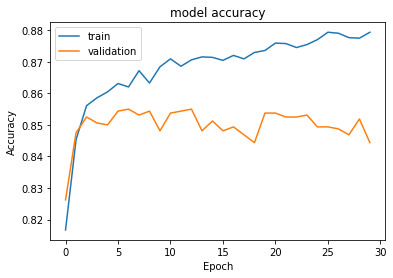

```python
#Plotting Train Accuracy vs Validation Accuracy
plt.plot(hist['accuracy'])
plt.plot(hist['val_accuracy'])
plt.title('model accuracy')
plt.ylabel('Accuracy')
plt.xlabel('Epoch')
plt.legend(['train', 'validation'], loc='upper left')
plt.show()
```

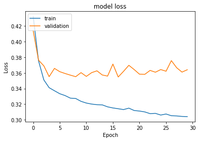

```python
#Plotting Train Loss vs Validation Loss
plt.plot(hist['loss'])
plt.plot(hist['val_loss'])
plt.title('model loss')
plt.ylabel('Loss')
plt.xlabel('Epoch')
plt.legend(['train', 'validation'], loc='upper left')
plt.show()
```

##### Prediction using the ANN model

```python
loss, acc = model.evaluate(X_test, y_test, verbose=0)
print('Accuracy: %.3f'  % acc)
print('Loss: %.3f' % loss)
```

```
WARNING:tensorflow:Falling back from v2 loop because of error: Failed to find data adapter that can handle input: <class 'pandas.core.frame.DataFrame'>, <class 'NoneType'>
Accuracy: 0.850
Loss: 0.367
```

Model has an accuracy of 85% on test data

```python
y_pred = model.predict(X_test)
```

```
WARNING:tensorflow:Falling back from v2 loop because of error: Failed to find data adapter that can handle input: <class 'pandas.core.frame.DataFrame'>, <class 'NoneType'>
```

##### Predicting the results using 0.5 as a threshold

```python
#Predicting the results using 0.5 as a threshold
y_pred = (y_pred > 0.5)
y_pred
```

```
array([[ True],
       [False],
       [False],
       ...,
       [False],
       [False],
       [False]])
```

##### Accuracy, Precision, Recall, and F1-Scores

```python
#Accuracy of 85% as per the classification report
from sklearn import metrics
cr=metrics.classification_report(y_test,y_pred)
print(cr)
```

```
              precision    recall  f1-score   support

           0       0.88      0.93      0.91      1589
           1       0.67      0.52      0.59       411

    accuracy                           0.85      2000
   macro avg       0.78      0.73      0.75      2000
weighted avg       0.84      0.85      0.84      2000
```

##### Confusion Matrix

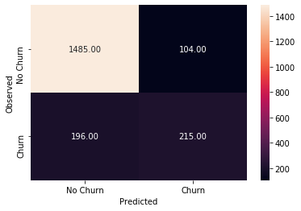

```python
cm = metrics.confusion_matrix(y_test, y_pred)
sns.heatmap(cm, annot=True,  fmt='.2f', xticklabels = ['No Churn','Churn'] , yticklabels = ['No Churn','Churn'] )
plt.ylabel('Observed')
plt.xlabel('Predicted')
plt.show()
```

- The ANN model has a 85% accuracy on test data (1700 out of 2000 records predicted accurately)
- However, based on the business problem, Recall is an important metric as all customers who exited needs to be predicted accurately by the model (i.e. minimize False Negatives)
- Based on the The ANN model has a Recall rate of 52%. 215 records were accurately predicted as churn. However, the model needs to minimize the 196 False Negatives (i.e model predicted no churn when the customers actually exited)

**Next Steps:**

1. Use SMOTE technique to solve the imbalance problem and then train the model in order to reduce the False Negatives
2. Find the best values for various hyperparameters (batch_size, epoch, activation function etc) using GridSearch to reduce False Negatives

### Upsample Training Data Set using SMOTE and train ANN

```python
import imblearn
```

```python
from imblearn.over_sampling import SMOTE
```

```python
print("Before UpSampling, counts of label '1': {}".format(sum(y_train==1)))
print("Before UpSampling, counts of label '0': {} \n".format(sum(y_train==0)))

smt = SMOTE(sampling_strategy = 1 ,k_neighbors = 5, random_state=1)
X_train_SMOTE, y_train_SMOTE = smt.fit_sample(X_train, y_train)

print("After UpSampling, counts of label '1': {}".format(sum(y_train_SMOTE==1)))
print("After UpSampling, counts of label '0': {} \n".format(sum(y_train_SMOTE==0)))



print('After UpSampling, the shape of train_X: {}'.format(X_train_SMOTE.shape))
print('After UpSampling, the shape of train_y: {} \n'.format(y_train_SMOTE.shape))
```

```
Before UpSampling, counts of label '1': 1626
Before UpSampling, counts of label '0': 6374

After UpSampling, counts of label '1': 6374
After UpSampling, counts of label '0': 6374

After UpSampling, the shape of train_X: (12748, 13)
After UpSampling, the shape of train_y: (12748,)
```

```python
#Feature Scaling/Normalizing the train and test data set
#X_train = preprocessing.normalize(X_train)
#X_test = preprocessing.normalize(X_test)
sc = StandardScaler()
X_train_SMOTE = sc.fit_transform(X_train_SMOTE)
```

```python
X_train_SMOTE = pd.DataFrame(X_train_SMOTE, columns=X_encoded.columns)
X_train
```

|  | CreditScore | Age | Tenure | Balance | NumOfProducts | HasCrCard | IsActiveMember | EstimatedSalary | Geography_France | Geography_Germany | Geography_Spain | Gender_Female | Gender_Male |
| --- | --- | --- | --- | --- | --- | --- | --- | --- | --- | --- | --- | --- | --- |
| 0 | -0.224828 | 0.099845 | 1.377789 | -1.234331 | -0.906787 | 0.643760 | -1.036672 | -1.736747 | 0.996257 | -0.575811 | -0.576003 | -0.915783 | 0.915783 |
| 1 | -0.835785 | -0.848578 | -1.037266 | 0.874085 | -0.906787 | 0.643760 | 0.964625 | -0.905804 | 0.996257 | -0.575811 | -0.576003 | -0.915783 | 0.915783 |
| 2 | -0.980758 | 0.668899 | -0.692259 | 0.879836 | -0.906787 | 0.643760 | 0.964625 | 0.145744 | -1.003757 | -0.575811 | 1.736102 | -0.915783 | 0.915783 |
| 3 | -0.276604 | 0.858584 | -0.692259 | 0.729389 | 0.808987 | -1.553374 | -1.036672 | -1.217237 | -1.003757 | 1.736682 | -0.576003 | 1.091962 | -1.091962 |
| 4 | 0.137604 | 0.194688 | -0.002243 | -1.234331 | -0.906787 | 0.643760 | 0.964625 | 0.902146 | 0.996257 | -0.575811 | -0.576003 | 1.091962 | -1.091962 |
| ... | ... | ... | ... | ... | ... | ... | ... | ... | ... | ... | ... | ... | ... |
| 7995 | -1.022179 | 0.574057 | 1.377789 | -1.234331 | 0.808987 | 0.643760 | -1.036672 | -1.273985 | -1.003757 | -0.575811 | 1.736102 | -0.915783 | 0.915783 |
| 7996 | 1.235256 | 0.668899 | 1.377789 | 1.825095 | -0.906787 | 0.643760 | 0.964625 | -1.482863 | -1.003757 | -0.575811 | 1.736102 | -0.915783 | 0.915783 |
| 7997 | 0.344708 | -0.374367 | 0.342765 | 0.945725 | -0.906787 | 0.643760 | 0.964625 | -0.223850 | 0.996257 | -0.575811 | -0.576003 | -0.915783 | 0.915783 |
| 7998 | 0.365418 | -0.469209 | 1.377789 | -1.234331 | 0.808987 | 0.643760 | -1.036672 | 0.476920 | -1.003757 | -0.575811 | 1.736102 | -0.915783 | 0.915783 |
| 7999 | 0.769271 | -1.227948 | 0.342765 | 0.349055 | -0.906787 | -1.553374 | -1.036672 | 0.583741 | 0.996257 | -0.575811 | -0.576003 | -0.915783 | 0.915783 |

8000 rows × 13 columns

```python
#Initializing, and Adding the hidden and output layers
model = Sequential()
model.add(Dense(26,activation='relu',input_dim = 13))
model.add(Dropout(0.1))
model.add(Dense(13,activation='relu'))
model.add(Dropout(0.1))
model.add(Dense(1, activation = 'sigmoid'))
#compile model
optimizer = tf.keras.optimizers.Adam(0.001)
model.compile(optimizer = optimizer,loss = 'binary_crossentropy', metrics = ['accuracy'])
history = model.fit(X_train_SMOTE,y_train_SMOTE,batch_size=40,epochs=100,verbose=1,validation_split = 0.2)
```

```
WARNING:tensorflow:Falling back from v2 loop because of error: Failed to find data adapter that can handle input: <class 'pandas.core.frame.DataFrame'>, <class 'NoneType'>
Train on 10198 samples, validate on 2550 samples
```

```python
y_pred = model.predict(X_test)
#Predicting the results using 0.5 as a threshold
y_pred = (y_pred > 0.5)
y_pred
```

```
WARNING:tensorflow:Falling back from v2 loop because of error: Failed to find data adapter that can handle input: <class 'pandas.core.frame.DataFrame'>, <class 'NoneType'>
```

```
array([[ True],
       [False],
       [False],
       ...,
       [False],
       [ True],
       [False]])
```

```python
cr=metrics.classification_report(y_test,y_pred)
print(cr)
```

```
              precision    recall  f1-score   support

           0       0.92      0.84      0.88      1589
           1       0.53      0.70      0.60       411

    accuracy                           0.81      2000
   macro avg       0.72      0.77      0.74      2000
weighted avg       0.84      0.81      0.82      2000
```

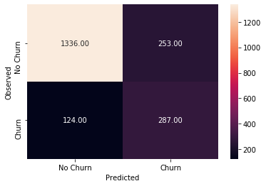

```python
cm = metrics.confusion_matrix(y_test, y_pred)
sns.heatmap(cm, annot=True,  fmt='.2f', xticklabels = ['No Churn','Churn'] , yticklabels = ['No Churn','Churn'] )
plt.ylabel('Observed')
plt.xlabel('Predicted')
plt.show()
```

- After applying SMOTE, the accuracy dropped to 81%
- Recall increased to 70% (from 52%)
- Oversampling using SMOTE helped reduce the False Negatives (124 after SMOTE)

### Tuning the ANN for the best Batch Size and Epoch

```python
from tensorflow.keras.wrappers.scikit_learn import KerasClassifier
from sklearn.model_selection import GridSearchCV
```

```python
#Function to create model, required for KerasClassifier
def create_model():
    model = Sequential()
    model.add(Dense(64,activation='relu',input_dim = 13))
    model.add(Dense(32,activation='relu'))
    model.add(Dense(1, activation = 'sigmoid'))
    #compile model
    optimizer = tf.keras.optimizers.RMSprop(0.001)
    model.compile(optimizer = optimizer,loss = 'binary_crossentropy', metrics = ['accuracy'])
    return model
```

```python
#Create Model
model = KerasClassifier(build_fn=create_model, verbose=1)\

# Define the grid search parameters
batch_size = [10,20,40]
epochs = [15,50,100]

# Make a dictionary of the grid search parameters
param_grid = dict(batch_size = batch_size,epochs = epochs)

# Build and fit the GridSearchCV
grid = GridSearchCV(estimator = model,param_grid = param_grid,cv = 3,verbose = 10)
grid_result = grid.fit(X_train,y_train)
```

[output not shown]

[output cut: 83 more lines]

[output not shown]

```python
#summarize results
print("Best: %f using %s" % (grid_result.best_score_, grid_result.best_params_))
```

```
Best: 0.856251 using {'batch_size': 40, 'epochs': 15}
```

### Tuning the ANN to find the best optimizer

```python
#Function to create model, required for KerasClassifier
def create_model(optimizer='adam'):
    model = Sequential()
    model.add(Dense(64,activation='relu',input_dim = 13))
    model.add(Dense(32,activation='relu'))
    model.add(Dense(1, activation = 'sigmoid'))
    #compile model
    model.compile(optimizer = optimizer,loss = 'binary_crossentropy', metrics = ['accuracy'])
    return model
```

```python
#Create Model
model = KerasClassifier(build_fn=create_model, epochs = 15, batch_size = 40, verbose=1)\

# Define the grid search parameters
optimizer = ['SGD', 'RMSprop', 'Adagrad', 'Adadelta', 'Adam', 'Adamax', 'Nadam']

# Make a dictionary of the grid search parameters
param_grid = dict(optimizer = optimizer)

# Build and fit the GridSearchCV
grid = GridSearchCV(estimator = model,param_grid = param_grid,cv = 3,verbose = 10)
grid_result = grid.fit(X_train,y_train)
```

[output not shown]

[output cut: 53 more lines]

[output not shown]

```python
print("Best: %f using %s" % (grid_result.best_score_, grid_result.best_params_))
```

```
Best: 0.856876 using {'optimizer': 'Nadam'}
```

### Tuning the ANN to find the best learning rate

```python
#Function to create model, required for KerasClassifier
def create_model(learn_rate=0.01):
    model = Sequential()
    model.add(Dense(64,activation='relu',input_dim = 13))
    model.add(Dense(32,activation='relu'))
    model.add(Dense(1, activation = 'sigmoid'))
    #compile model
    optimizer = tf.keras.optimizers.Nadam(learn_rate)
    model.compile(optimizer = optimizer,loss = 'binary_crossentropy', metrics = ['accuracy'])
    return model
```

```python
#Create Model
model = KerasClassifier(build_fn=create_model, epochs = 15, batch_size = 40, verbose=1)\

# Define the grid search parameters
learn_rate = [0.001, 0.01, 0.1, 0.2, 0.3]

# Make a dictionary of the grid search parameters
param_grid = dict(learn_rate = learn_rate)

# Build and fit the GridSearchCV
grid = GridSearchCV(estimator = model,param_grid = param_grid,cv = 3,verbose = 10)
grid_result = grid.fit(X_train,y_train)
```

[output not shown]

[output cut: 23 more lines]

[output not shown]

```python
print("Best: %f using %s" % (grid_result.best_score_, grid_result.best_params_))
```

```
Best: 0.856877 using {'learn_rate': 0.001}
```

### Tuning the ANN to find the best dropout rate

```python
#Function to create model, required for KerasClassifier
def create_model(dropout_rate=0.0):
    model = Sequential()
    model.add(Dense(64,activation='relu',input_dim = 13))
    model.add(Dropout(dropout_rate))
    model.add(Dense(32,activation='relu'))
    model.add(Dropout(dropout_rate))
    model.add(Dense(1, activation = 'sigmoid'))
    #compile model
    optimizer = tf.keras.optimizers.Nadam(0.001)
    model.compile(optimizer = optimizer,loss = 'binary_crossentropy', metrics = ['accuracy'])
    return model
```

```python
#Create Model
model = KerasClassifier(build_fn=create_model, epochs = 15, batch_size = 40, verbose=1)\

# Define the grid search parameters
dropout_rate = [0.0, 0.1, 0.2, 0.3, 0.4]

# Make a dictionary of the grid search parameters
param_grid = dict(dropout_rate = dropout_rate)

# Build and fit the GridSearchCV
grid = GridSearchCV(estimator = model,param_grid = param_grid,cv = 3,verbose = 10)
grid_result = grid.fit(X_train,y_train)
```

[output not shown]

[output cut: 23 more lines]

[output not shown]

```python
#summarize results
print("Best: %f using %s" % (grid_result.best_score_, grid_result.best_params_))
```

```
Best: 0.858626 using {'dropout_rate': 0.2}
```

### Tuning the ANN for the best activation function

```python
#Function to create model, required for KerasClassifier
def create_model(activation_function):
    model = Sequential()
    model.add(Dense(64,activation=activation_function,input_dim = 13))
    model.add(Dropout(0.2))
    model.add(Dense(32,activation=activation_function))
    model.add(Dropout(0.2))
    model.add(Dense(1, activation = 'sigmoid'))
    #compile model
    optimizer = tf.keras.optimizers.Nadam(0.001)
    model.compile(optimizer = optimizer,loss = 'binary_crossentropy', metrics = ['accuracy'])
    return model
```

```python
#Create Model
model = KerasClassifier(build_fn=create_model, epochs = 15, batch_size = 40, verbose=1)\

# Define the grid search parameters
activation_function = ['softmax','relu','tanh']

# Make a dictionary of the grid search parameters
param_grid = dict(activation_function = activation_function)

# Build and fit the GridSearchCV
grid = GridSearchCV(estimator = model,param_grid = param_grid,cv = 3,verbose = 10)
grid_result = grid.fit(X_train,y_train)
```

[output not shown]

```python
#summarize results
print("Best: %f using %s" % (grid_result.best_score_, grid_result.best_params_))
```

```
Best: 0.859125 using {'activation_function': 'tanh'}
```

### Tuning the ANN for the best number of neurons

```python
#Function to create model, required for KerasClassifier
def create_model(n1,n2):
    model = Sequential()
    model.add(Dense(n1,activation='tanh',input_dim = 13))
    model.add(Dropout(0.2))
    model.add(Dense(n2,input_dim = n1, activation='tanh'))
    model.add(Dropout(0.2))
    model.add(Dense(1, activation = 'sigmoid'))
    #compile model
    optimizer = tf.keras.optimizers.Nadam(0.001)
    model.compile(optimizer = optimizer,loss = 'binary_crossentropy', metrics = ['accuracy'])
    return model
```

```python
#Create Model
model = KerasClassifier(build_fn=create_model, epochs = 15, batch_size = 40, verbose=1)\

# Define the grid search parameters
n1 = [7,13,26]
n2 = [4,7,13]

# Make a dictionary of the grid search parameters
param_grid = dict(n1 = n1,n2 = n2)

# Build and fit the GridSearchCV
grid = GridSearchCV(estimator = model,param_grid = param_grid,cv = 3,verbose = 10)
grid_result = grid.fit(X_train,y_train)
```

[output not shown]

[output cut: 83 more lines]

[output not shown]

```python
#summarize results
print("Best: %f using %s" % (grid_result.best_score_, grid_result.best_params_))
```

```
Best: 0.846625 using {'n1': 26, 'n2': 13}
```

### Summary of the best Hyperparameter values

- Number of Layer 1 Neurons: 26
- Number of Layer 2 Nuerons: 13
- Activation Function: Tanh
- Dropout Rate: 0.2
- Learn Rate: 0.001
- Optimizer: Nadam
- Batch_size: 40
- Epochs: 15

### Training the ANN with the best Hyperparameter values

```python
#Initializing, and Adding the hidden and output layers
model = Sequential()
model.add(Dense(26,activation='tanh',input_dim = 13))
model.add(Dropout(0.2))
model.add(Dense(13,activation='tanh'))
model.add(Dropout(0.2))
model.add(Dense(1, activation = 'sigmoid'))
#compile model
optimizer = tf.keras.optimizers.Nadam(0.001)
model.compile(optimizer = optimizer,loss = 'binary_crossentropy', metrics = ['accuracy'])
history = model.fit(X_train_SMOTE,y_train_SMOTE,batch_size=40,epochs=15,verbose=1,validation_split = 0.2)
```

```
WARNING:tensorflow:Falling back from v2 loop because of error: Failed to find data adapter that can handle input: <class 'pandas.core.frame.DataFrame'>, <class 'NoneType'>
Train on 10198 samples, validate on 2550 samples
```

```python
hist  = pd.DataFrame(history.history)
hist['epoch'] = history.epoch
print(hist)
```

```
        loss  accuracy  val_loss  val_accuracy  epoch
0   0.604363  0.680526  0.771144      0.527451      0
1   0.561833  0.716415  0.779615      0.524706      1
2   0.549688  0.719259  0.759246      0.545882      2
3   0.532680  0.730143  0.703623      0.598824      3
4   0.522844  0.738184  0.705087      0.599608      4
5   0.507183  0.748872  0.682800      0.628235      5
6   0.501653  0.757207  0.667350      0.640000      6
7   0.495493  0.757796  0.673702      0.632941      7
8   0.495302  0.756031  0.652629      0.657255      8
9   0.488273  0.761914  0.689500      0.623137      9
10  0.484906  0.767896  0.661894      0.649020     10
11  0.480494  0.769367  0.676440      0.633333     11
12  0.475286  0.774662  0.683738      0.626667     12
13  0.480441  0.771328  0.648335      0.652549     13
14  0.478423  0.771426  0.649482      0.647843     14
```

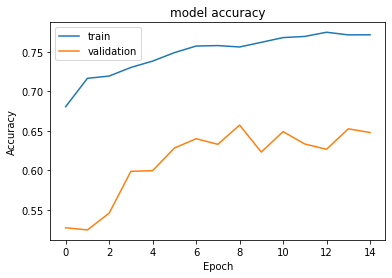

```python
#Plotting Train Accuracy vs Validation Accuracy
plt.plot(hist['accuracy'])
plt.plot(hist['val_accuracy'])
plt.title('model accuracy')
plt.ylabel('Accuracy')
plt.xlabel('Epoch')
plt.legend(['train', 'validation'], loc='upper left')
plt.show()
```

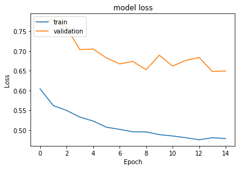

```python
#Plotting Train Loss vs Validation Loss
plt.plot(hist['loss'])
plt.plot(hist['val_loss'])
plt.title('model loss')
plt.ylabel('Loss')
plt.xlabel('Epoch')
plt.legend(['train', 'validation'], loc='upper left')
plt.show()
```

```python
loss, acc = model.evaluate(X_test, y_test, verbose=0)
print('Accuracy: %.3f'  % acc)
print('Loss: %.3f' % loss)
```

```
WARNING:tensorflow:Falling back from v2 loop because of error: Failed to find data adapter that can handle input: <class 'pandas.core.frame.DataFrame'>, <class 'NoneType'>
Accuracy: 0.786
Loss: 0.453
```

```python
y_pred = model.predict(X_test)
#Predicting the results using 0.5 as a threshold
y_pred = (y_pred > 0.5)
y_pred
```

```
WARNING:tensorflow:Falling back from v2 loop because of error: Failed to find data adapter that can handle input: <class 'pandas.core.frame.DataFrame'>, <class 'NoneType'>
```

```
array([[False],
       [False],
       [False],
       ...,
       [False],
       [ True],
       [False]])
```

```python
cr=metrics.classification_report(y_test,y_pred)
print(cr)
```

```
              precision    recall  f1-score   support

           0       0.92      0.80      0.86      1589
           1       0.49      0.74      0.59       411

    accuracy                           0.79      2000
   macro avg       0.70      0.77      0.72      2000
weighted avg       0.83      0.79      0.80      2000
```

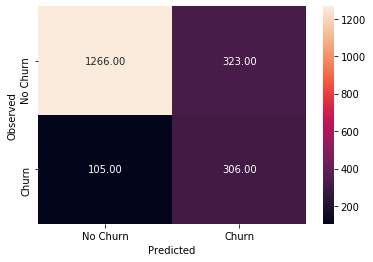

```python
cm = metrics.confusion_matrix(y_test, y_pred)
sns.heatmap(cm, annot=True,  fmt='.2f', xticklabels = ['No Churn','Churn'] , yticklabels = ['No Churn','Churn'] )
plt.ylabel('Observed')
plt.xlabel('Predicted')
plt.show()
```